# Attainment and Attendance in Arun

What the national model behind *How to Pull the Right Lever* says about the district’s secondary schools, within West Sussex and alongside Brighton and Hove. **Draft for discussion.**

Author

Affiliation

Adam Dennett

Bartlett Centre for Advanced Spatial Analysis, University College London

Published

October 31, 2026

**WarningDraft for discussion**

One of the district documents for Sussex. It sits beneath the West Sussex document, and the district summary compares all of the districts. Every figure comes from published Department for Education data and the national models of [How to Pull the Right Lever](https://adamdennett.github.io/school_attainment_tool/pulling_the_right_lever_v2.html). Nothing uses pupil-level records. The commentary is written to a common pattern from the figures; read it as a starting point for discussion.

# Summary

**Arun’s results are among the weakest of England’s districts, on an intake less disadvantaged than England’s.** Its 6 state secondary schools are in Bognor Regis, Chichester, Littlehampton and West Sussex.

- **Overall results:** 43.1 in Attainment 8 in 2024/25, 215th of 264 districts in England.
- **Disadvantage:** 18.6% of pupils are disadvantaged, against 28.3% nationally.
- **Disadvantaged pupils average 31.2**, below the national 37.8 (248th of 264).
- **The gap between disadvantaged pupils and the rest is 14.6 points**, the 70th widest of 264.

The other findings:

- **For all pupils, Arun is 3.3 points below England.** The largest pieces in the national model are prior attainment (-1.9) and absence (-0.8). The district’s schools take 0.7 points beyond what the model expects.
- **For disadvantaged pupils it is 5.3 points below England.** The largest pieces are West Sussex’s county-wide effect (-1.5) and being in the South East (-1.3), and the schools take 0.5 points beyond what the model expects.
- **No district effect can be found.** Once intake, West Sussex’s county effect and the schools themselves are accounted for, nothing is left that all Arun schools share.
- **3 of the 6 schools are above expectation** over 2021/22 to 2024/25. The strongest is The Regis School (+2.4); the weakest The Littlehampton Academy (-3.5).
- **Absence was 8.7%** in autumn and spring 2025/26 (9.1% a year earlier), against 8.0% for England and 8.1% for West Sussex. Over 2021/22 to 2024/25 its schools ran 0.3 points above what their intakes predict, and The Littlehampton Academy more than a point above.
- **Reduced timetables run at 0.9 times the national rate, and suspensions at 0.9 times** (19.3 per 100 pupils, against 21.2).
- **Disadvantaged groups are small,** 17 to 72 pupils a year per school. Every school-level figure for them moves from year to year and should be read over several years.

# 1 About this analysis

Arun is a district of West Sussex, not a local authority, and that shapes what can be said:

- **The national models place schools in local authorities.** The “local authority effect” in this document is West Sussex’s, shared with every school in the county.
- **What is particular to Arun** shows up in its schools’ own residuals, and in the district test of Section 6.
- **Absence and exclusions** are summed over the district’s 6 schools, followed through any change of URN.

The methods are described in full in the East Sussex document.

# 2 The district’s schools

[interactive chart not shown]

Arun’s state-funded secondary schools, coloured by overall absence in 2024/25. Choose another measure from the menu above the map; circle size is the school’s roll. Hover for figures and who runs each school.

Every state-funded secondary school in the district, 2024/25, with the size of its disadvantaged Year 11 group.

| School | Town | Type | Pupils | FSM % | Disadvantaged in Year 11 | Absence % | KS2 | Att 8 | Att 8 disadv. | Ofsted |
| --- | --- | --- | --- | --- | --- | --- | --- | --- | --- | --- |
| Felpham Community College | Bognor Regis | Maintained | 1557 | 16.3 | 43 | 8.8 | 3.7 | 41.9 | 29.7 | Good |
| St Philip Howard Catholic School | Bognor Regis | Academy | 1301 | 14.2 | 30 | 6.9 | 4.6 | 52.5 | 37.5 | Outstanding |
| Ormiston Six Villages Academy | Chichester | Academy | 698 | 15.3 | 17 | 7.8 | 2.6 | 42.8 | 30.7 | Good |
| The Angmering School | Littlehampton | Maintained | 1345 | 16.9 | 44 | 10.3 | 3.0 | 41.0 | 27.2 | Good |
| The Littlehampton Academy | Littlehampton | Academy | 1369 | 23.7 | 56 | 12.7 | 3.7 | 37.2 | 26.7 | Good |
| The Regis School | West Sussex | Academy | 1665 | 25.3 | 72 | 8.1 | 2.2 | 43.5 | 35.4 | Good |

2 of the 6 schools are maintained by West Sussex County Council. The academies are run as follows:

- **Ormiston Six Villages Academy**, in Ormiston Academies Trust (sponsored);
- **St Philip Howard Catholic School**, in Bosco Catholic Education Trust;
- **The Littlehampton Academy**, in Woodard Academies Trust (sponsored);
- **The Regis School**, in United Learning Trust (sponsored);

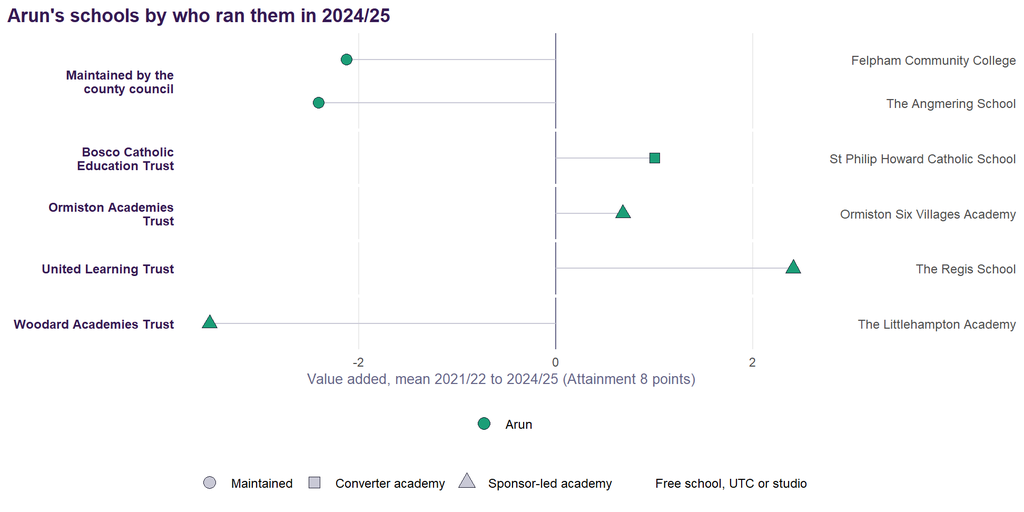

Figure 1: Who ran each school in 2024/25, and how far its results sat above or below the national model’s expectation over 2021/22 to 2024/25.

# 3 How Arun compares

Arun against West Sussex, Brighton and Hove and England, 2024/25. Means of school-level figures.

| Measure | Arun | West Sussex | Brighton and Hove | England |
| --- | --- | --- | --- | --- |
| Attainment 8, all pupils | 43.1 | 46.4 | 45.5 | 46.8 |
| Attainment 8, disadvantaged | 31.2 | 33.5 | 33.9 | 37.7 |
| Attainment 8, non-disadvantaged | 45.8 | 48.9 | 49.6 | 49.9 |
| Disadvantage gap (points) | 14.6 | 15.4 | 15.7 | 12.2 |
| Disadvantaged (FSM6) % | 18.6 | 17.1 | 28.8 | 28.4 |
| Overall absence % | 9.1 | 8.7 | 11.3 | 8.6 |
| Persistent absence % | 26.3 | 23.9 | 30.6 | 23.9 |
| Mean KS2 (centred) | 3.30 | 4.26 | 4.71 | 4.47 |
| EAL % | 11.1 | 11.0 | 13.0 | 18.4 |

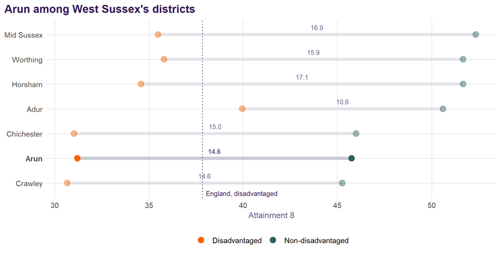

Figure 2: Attainment 8 for disadvantaged and non-disadvantaged pupils in West Sussex’s districts, 2024/25, school means. The gap between the two is printed on each district’s line; Arun is in bold.

Across the years the model covers, the gap was 15.0 points in 2021/22 and 14.6 in 2024/25. Arun’s non-disadvantaged pupils were above England’s average in 0 of 4 years, and its disadvantaged pupils in 0.

# 4 What explains attainment in Arun

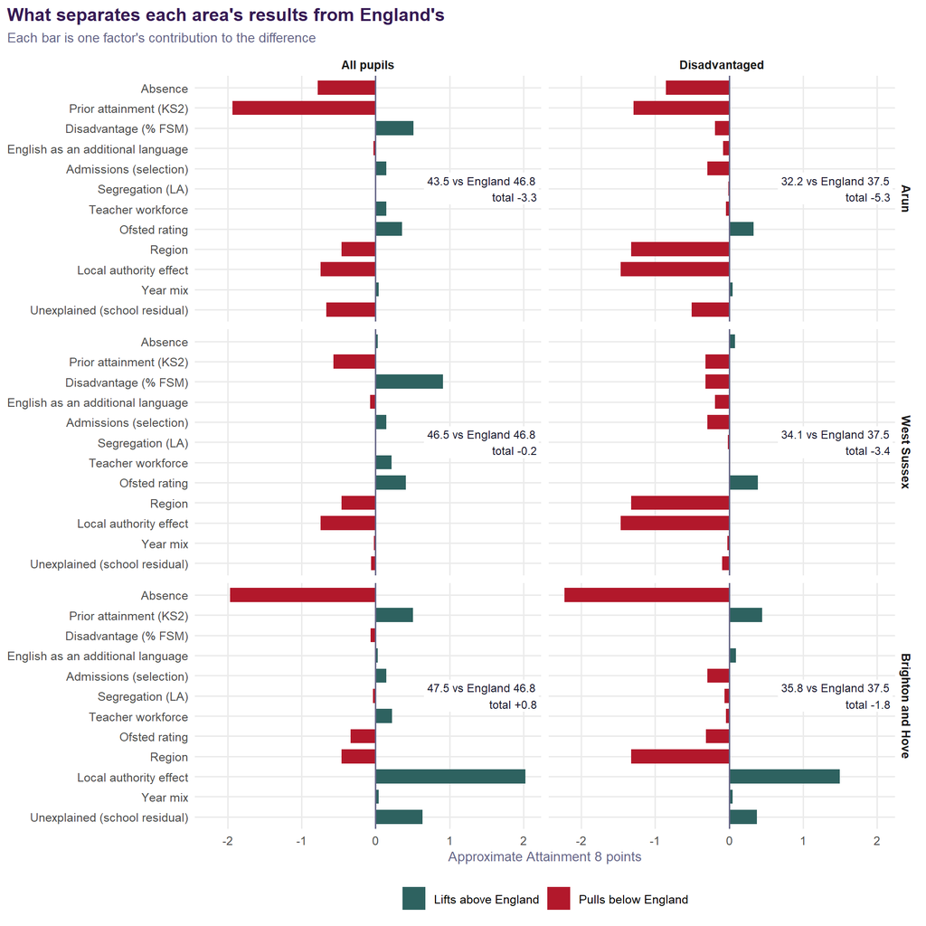

Figure 3: Why average Attainment 8 differs from England’s, by factor, all school-years 2021/22 to 2024/25, for Arun, West Sussex and Brighton and Hove. Approximate Attainment 8 points; the pieces sum to the total in each panel.

The decomposition for Arun, in Attainment 8 points. ‘Place’ is West Sussex’s effect plus the South East’s; ‘unexplained’ is what the district’s own schools add beyond everything the model accounts for.

| Factor | All pupils | Disadvantaged | Non-disadvantaged |
| --- | --- | --- | --- |
| Prior attainment (KS2) | -1.93 | -1.29 | -1.84 |
| Place (region and local authority) | -1.20 | -2.79 | -1.48 |
| Absence | -0.78 | -0.86 | -0.62 |
| Unexplained (school residual) | -0.66 | -0.50 | -0.82 |
| English as an additional language | -0.03 | -0.08 | -0.04 |
| Teacher workforce | +0.14 | -0.04 | +0.12 |
| Other model terms | +0.18 | -0.26 | +0.16 |
| Ofsted rating | +0.36 | +0.33 | +0.33 |
| Disadvantage (% FSM) | +0.52 | -0.19 | +0.28 |

**For all pupils**, Arun is 3.3 points below England. The pieces of at least a quarter of a point:

- prior attainment (-1.93);
- absence (-0.78);
- West Sussex’s county-wide effect (-0.74);
- the level of disadvantage (+0.52);
- being in the South East (-0.46);
- Ofsted ratings (+0.36);
- and the district’s schools themselves (-0.66), beyond what the model expects.

**For disadvantaged pupils**, Arun is 5.3 points below England. The pieces of at least a quarter of a point:

- West Sussex’s county-wide effect (-1.47);
- being in the South East (-1.32);
- prior attainment (-1.29);
- absence (-0.86);
- Ofsted ratings (+0.33);
- admissions (-0.30);
- and the district’s schools themselves (-0.50), beyond what the model expects.

# 5 The disadvantaged gap, school by school

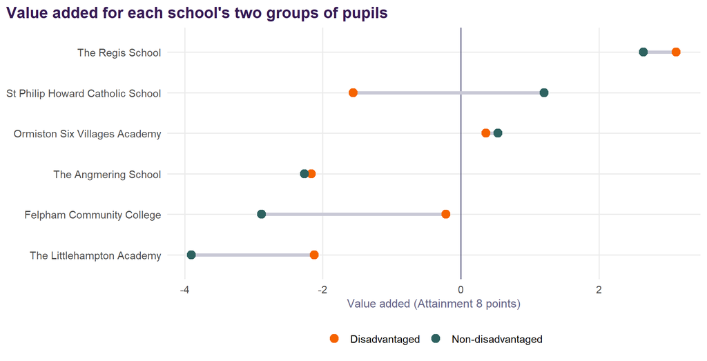

Figure 4: Each school’s value added for its disadvantaged and non-disadvantaged pupils, mean over the years available (2021/22 to provisional 2025/26). Above zero means better than the national model expects for similar pupils.

1 of the 6 schools is above expectation for non-disadvantaged pupils and more than a point below it for disadvantaged ones: St Philip Howard Catholic School. The Regis School and Ormiston Six Villages Academy are above expectation for both groups. The table below gives each school’s own persistent effect, from the model with a school term, which is the steadier measure.

Table 1: Each school’s own persistent effect on the national model with a school term (%), for each group of pupils and for absence beyond what its intake predicts. Positive absence is worse.

| School | All pupils | Disadvantaged | Non-disadvantaged | Absence (stage 1) |
| --- | --- | --- | --- | --- |
| Felpham Community College | -4.4 | +0.7 | -5.0 | +9.4 |
| The Angmering School | -5.3 | -4.9 | -4.6 | +5.2 |
| The Littlehampton Academy | -8.6 | -4.6 | -8.3 | +26.3 |
| The Regis School | +4.7 | +7.0 | +3.9 | -2.3 |
| Ormiston Six Villages Academy | +2.1 | -2.2 | +2.6 | -3.2 |
| St Philip Howard Catholic School | +3.0 | -2.8 | +3.9 | -13.7 |

Table 2: Attainment 8 of each school’s disadvantaged pupils, year by year (2025/26 provisional), with the size of the group in 2024/25. Small groups make single years unreliable.

| School | 2021/22 | 2022/23 | 2023/24 | 2024/25 | 2025/26 | Disadvantaged pupils, 2024/25 |
| --- | --- | --- | --- | --- | --- | --- |
| The Angmering School | 28.1 | 34.8 | 27.4 | 27.2 | 30.9 | 44 |
| Felpham Community College | 38.1 | 36.5 | 29.8 | 29.7 | 31.5 | 43 |
| The Littlehampton Academy | 29.8 | 28.6 | 27.5 | 26.7 | 27.2 | 56 |
| Ormiston Six Villages Academy | 37.8 | 27.3 | 27.8 | 30.7 | 38.1 | 17 |
| The Regis School | 37.1 | 34.7 | 33.9 | 35.4 | 37.2 | 72 |
| St Philip Howard Catholic School | 34.7 | 38.8 | 40.9 | 37.5 | 39.4 | 30 |

# 6 Is there an Arun effect?

The district test of the East Sussex document adds a district level to the national model, with and without each school’s own record.

Table 3: The Arun district effect, over and above West Sussex’s, with 95% intervals.

| Specification | Outcome | Effect (%) | 95% interval | Significant |
| --- | --- | --- | --- | --- |
| Published specification | All pupils | -1.4 | -4.5 to +1.9 | No |
| Published specification | Disadvantaged | -1.5 | -5.2 to +2.4 | No |
| Published specification | Non-disadvantaged | -1.9 | -4.7 to +0.9 | No |
| Published specification | Absence (stage 1) | +1.9 | -4.9 to +9.2 | No |
| With a school term | All pupils | -0.6 | -3.8 to +2.7 | No |
| With a school term | Disadvantaged | -0.5 | -3.5 to +2.7 | No |
| With a school term | Non-disadvantaged | -1.3 | -4.5 to +2.0 | No |
| With a school term | Absence (stage 1) | +0.6 | -5.1 to +6.5 | No |

None of Arun’s district effects can be told apart from zero on either specification. The district’s results are explained by its intake, West Sussex’s county effect and its individual schools.

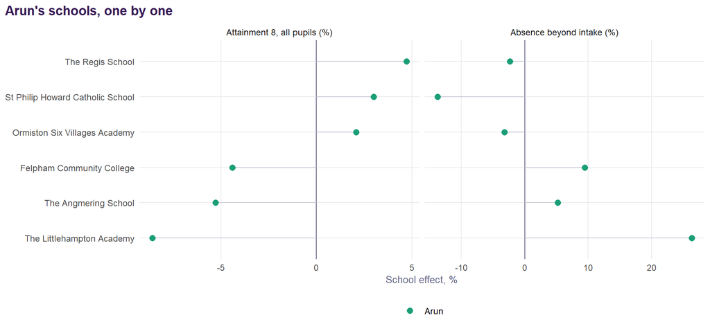

Figure 5: Each school’s own persistent effect, from the model with a school term: Attainment 8 for all pupils, and absence beyond what its intake predicts.

# 7 Absence

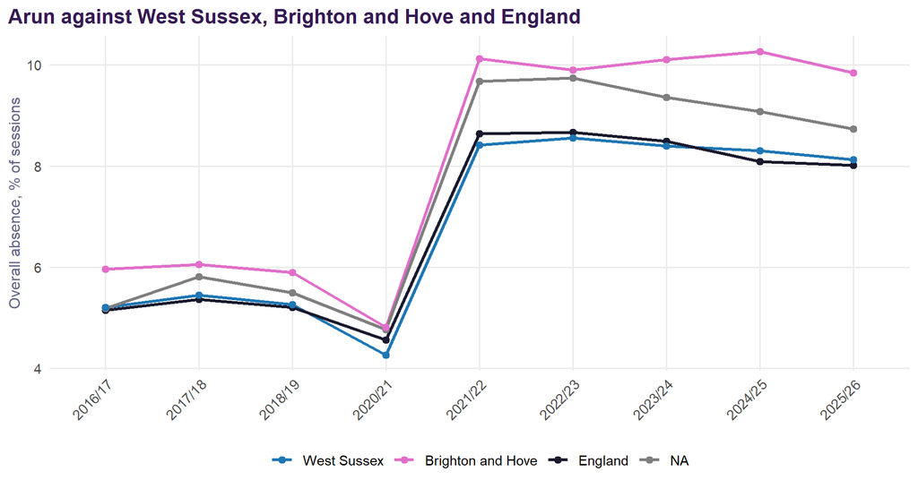

Figure 6: Overall absence, autumn and spring terms, 2016/17 to 2025/26. Sessions-weighted; 2019/20 not collected.

- **8.7% absence** in autumn and spring 2025/26, against 8.0% for England and 8.1% for West Sussex. A year earlier it was 9.1%.
- **Persistent absence** is 24.0%, against 21.6% for England.
- **Against its intake**, the district’s schools run 0.32 points above what their pupils’ profiles predict, on average over 2021/22 to 2024/25.

Table 4: Each school’s absence against what its intake predicts, mean 2021/22 to 2024/25, and its reasons in the latest year (percentage of sessions).

| School | Absence % | Predicted by intake % | Above prediction | Illness | Unauthorised | Reduced timetable | Suspended |
| --- | --- | --- | --- | --- | --- | --- | --- |
| The Littlehampton Academy | 12.2 | 9.7 | +2.4 | 6.0 | 3.2 | 0.57 | 0.55 |
| Felpham Community College | 9.6 | 8.6 | +1.0 | 4.6 | 2.1 | 0.41 | 0.14 |
| The Angmering School | 10.0 | 9.6 | +0.3 | 4.0 | 3.0 | 0.24 | 0.20 |
| The Regis School | 9.1 | 9.5 | -0.4 | 4.3 | 2.2 | 0.08 | 0.11 |
| Ormiston Six Villages Academy | 9.2 | 9.7 | -0.5 | 5.2 | 2.2 | 0.09 | 0.11 |
| St Philip Howard Catholic School | 6.9 | 7.8 | -0.9 | 4.3 | 0.9 | 0.15 | 0.05 |

- **The Littlehampton Academy** runs more than a point above its predicted absence.

Reduced timetables account for 0.27% of sessions, against 0.29% in England, 0.9 times the national rate. The Littlehampton Academy’s rate is the highest in the district.

Table 5: Predicted Attainment 8 gain if each school’s absence fell to the national school average (2024/25). Indicative only.

| School | District | Absence % | FSM % | Gain, all pupils | Gain, disadvantaged | Gain from FSM to area average |
| --- | --- | --- | --- | --- | --- | --- |
| The Littlehampton Academy | Arun | 12.7 | 23.7 | +3.1 | +3.3 | +0.5 |
| The Angmering School | Arun | 10.3 | 16.9 | +1.6 | +1.5 | +0.0 |
| Felpham Community College | Arun | 8.8 | 16.3 | +0.3 | +0.3 | +0.0 |
| The Regis School | Arun | 8.1 | 25.3 | +0.0 | +0.0 | +0.7 |

3 of the 6 schools are above the national average absence in 2024/25. Bringing them to it would add up to 3.1 points for all pupils, as an indication of scale.

**Suspensions** were 19.3 per 100 pupils in 2024/25, against 21.2 for England and 16.2 for West Sussex.

Table 6: Suspensions per 100 pupils and permanent exclusions, by school, latest year.

| School | Pupils | Suspensions per 100 | Permanent exclusions |
| --- | --- | --- | --- |
| The Littlehampton Academy | 1369 | 56.2 | 9 |
| The Angmering School | 1345 | 17.3 | 8 |
| Ormiston Six Villages Academy | 698 | 14.3 | 0 |
| Felpham Community College | 1557 | 13.6 | 0 |
| The Regis School | 1665 | 8.8 | 2 |
| St Philip Howard Catholic School | 1301 | 5.2 | 0 |

# 8 Contextual league tables

**All pupils**

Value added, all pupils: observed Attainment 8 minus the national model’s expectation. 2025/26 is provisional.

| School | 2021/22 | 2022/23 | 2023/24 | 2024/25 | 2025/26 | Mean | Years |
| --- | --- | --- | --- | --- | --- | --- | --- |
| The Regis School | +6.1 | +1.2 | +1.5 | +0.3 | +4.7 | +2.8 | 5 |
| St Philip Howard Catholic School | +0.5 | -0.0 | +2.0 | +1.6 | -0.6 | +0.7 | 5 |
| Ormiston Six Villages Academy | +2.7 | +0.1 | +0.5 | -0.8 | +0.2 | +0.6 | 5 |
| Felpham Community College | +0.3 | -2.7 | -3.2 | -3.0 | -3.1 | -2.3 | 5 |
| The Angmering School | -1.7 | -2.8 | -3.8 | -1.4 | -2.8 | -2.5 | 5 |
| The Littlehampton Academy | -3.0 | -5.6 | -2.7 | -2.9 | -4.4 | -3.7 | 5 |

**Disadvantaged pupils**

Value added, disadvantaged pupils. Small groups; read across years.

| School | 2021/22 | 2022/23 | 2023/24 | 2024/25 | 2025/26 | Mean | Years |
| --- | --- | --- | --- | --- | --- | --- | --- |
| The Regis School | +5.4 | +3.0 | +1.5 | +2.3 | +3.4 | +3.1 | 5 |
| Ormiston Six Villages Academy | +5.2 | -4.7 | -3.4 | -1.5 | +6.3 | +0.4 | 5 |
| Felpham Community College | +3.1 | +4.1 | -1.9 | -3.0 | -3.3 | -0.2 | 5 |
| St Philip Howard Catholic School | -8.4 | -0.9 | +2.1 | -0.5 | -0.2 | -1.6 | 5 |
| The Littlehampton Academy | -1.6 | -1.2 | -1.9 | -2.5 | -3.3 | -2.1 | 5 |
| The Angmering School | -5.5 | +3.2 | -3.2 | -2.8 | -2.5 | -2.2 | 5 |

**Non-disadvantaged pupils**

Value added, non-disadvantaged pupils.

| School | 2021/22 | 2022/23 | 2023/24 | 2024/25 | 2025/26 | Mean | Years |
| --- | --- | --- | --- | --- | --- | --- | --- |
| The Regis School | +5.8 | +0.7 | +1.5 | +0.1 | +5.1 | +2.6 | 5 |
| St Philip Howard Catholic School | +2.0 | +0.5 | +2.1 | +1.9 | -0.4 | +1.2 | 5 |
| Ormiston Six Villages Academy | +2.1 | +1.5 | +1.5 | -1.0 | -1.4 | +0.5 | 5 |
| The Angmering School | -0.4 | -3.8 | -4.0 | -1.3 | -1.9 | -2.3 | 5 |
| Felpham Community College | -0.4 | -4.1 | -3.6 | -3.4 | -3.0 | -2.9 | 5 |
| The Littlehampton Academy | -3.0 | -6.7 | -2.7 | -3.2 | -3.9 | -3.9 | 5 |

# 9 Questions for discussion

1. **Disadvantaged pupils.** They average 31.2 in Arun against 37.8 in England, and the district’s schools take 0.5 points for them beyond what the model expects. What do The Regis School and Ormiston Six Villages Academy, above expectation for these pupils, do that the district’s other schools could share?
2. **Attendance is a modest lever.** Absence costs the district 0.8 points against England for all pupils, and The Littlehampton Academy run more than a point above what their intakes predict.
3. **Schools, not the place.** There is no Arun district effect: the differences that matter are between its schools.
4. **Practice.** Reduced timetables and suspensions are close to or below the national rate.
5. **The county.** West Sussex’s own effect for disadvantaged pupils is -3.8% (131st of 151), distinguishable from zero, and it applies to every school here. The county questions in the West Sussex document apply here as well.

# Notes on method

Methods and sources are those of the East Sussex document. District membership comes from each school’s postcode (ONS postcode directory, via postcodes.io). Absence and exclusions for the district are summed over its schools, including any predecessor or successor URNs. This document is generated from `templates/district_report.qmd` by `R/20_district_reports.R`, from data built by `R/17_area_analysis.R`, `R/18_district_effects.R` and `R/19_trust_effects.R`. Its format is described in `AREA_REPORTS.md`.